# Analysis of The Safety of Self Driving Cars

Anonymous

2024-11-11

# Research Question:

How do geographic and environmental characteristics effect the severity and the frequency of accidents in the United States?

# Relevance

Understanding the relationship between geographic and environmental factors and traffic accidents is critical as will help in priortizing safety interventions and guide infrastructure updates, like better road contions, lighting etc.

## Primary Source:

The dataset is from a Countrywide Traffic accident reports dataset published by Arxivs.

## Secondary Source:

The dataset is ZipDemography which is taken from dcData package.

## Challenges faced

The dataset was very large (almost 3GB) and I needed a way to decrease the query times without effecting the quality of the analysis. I decided to use the fread function to read the csv instead of read_csv since it is much faster to read. Also I created a smaller dataset of 100,000 random rows instead of the original 7 million. This improved the query times and still gave me a good sample to work with.

## Load packages and data

```r
library(readr)
library(dplyr)
#Using data.table library to use 'fread'. I found this resource while researching online and is used to load large datasets. This is much faster than read_csv
library(data.table)
library(tidyverse)
library(dcData)
data("ZipDemography")
cleaned_accident_data <- fread("US_Accidents_March23_100K.csv")
head(cleaned_accident_data, 4)
```

| ID | Source | Severity | Start_Time | End_Time | Start_Lat | Start_Lng | End_Lat | End_Lng | Distance(mi) | Description | Street | City | County | State | Zipcode | Country | Timezone | Airport_Code | Weather_Timestamp | Temperature(F) | Wind_Chill(F) | Humidity(%) | Pressure(in) | Visibility(mi) | Wind_Direction | Wind_Speed(mph) | Precipitation(in) | Weather_Condition | Amenity | … |
| --- | --- | --- | --- | --- | --- | --- | --- | --- | --- | --- | --- | --- | --- | --- | --- | --- | --- | --- | --- | --- | --- | --- | --- | --- | --- | --- | --- | --- | --- | --- |
| A-2027605 | Source2 | 3 | 2019-08-16 07:34:49 | 2019-08-16 08:19:36 | 42.89925 | -87.93680 | NA | NA | 2.210 | Entry ramp to I-94 Southbound from W Drexel Ave Eastbound closed. | I-41 S | Oak Creek | Milwaukee | WI | 53154 | US | US/Central | KMKE | 2019-08-16 07:52:00 | 68.0 | 68 | 78 | 29.19 | 10 | S | 6.0 | 0.00 | Mostly Cloudy | FALSE | … |
| A-3344552 | Source2 | 2 | 2017-07-27 07:47:42 | 2017-07-27 08:17:29 | 39.64832 | -85.97523 | NA | NA | 0.000 | Accident on Inspiration Dr at Crackling Ln. | Crackling Ln | Indianapolis | Marion | IN | 46259-7754 | US | US/Eastern | KGEZ | 2017-07-27 07:53:00 | 75.0 | NA | 87 | 29.94 | 5 | SW | 4.6 | 0.01 | Light Rain | FALSE | … |
| A-4361091 | Source1 | 2 | 2023-01-21 20:50:13 | 2023-01-22 06:50:51 | 30.48794 | -84.31672 | 30.4875 | -84.31722 | 0.043 | Accident | N Monroe St | Tallahassee | Leon | FL | 32303-2821 | US | US/Eastern | KTLH | 2023-01-21 20:53:00 | 51.0 | 51 | 86 | 29.97 | 10 | E | 9.0 | 0.00 | Cloudy | FALSE | … |
| A-3279631 | Source2 | 2 | 2017-09-01 12:28:54 | 2017-09-01 12:58:31 | 43.08863 | -83.71620 | NA | NA | 0.000 | Accident on Daron Pl at Bermuda Ln. | Bermuda Ln | Flint | Genesee | MI | 48505-1074 | US | US/Eastern | KFNT | 2017-09-01 12:53:00 | 62.1 | NA | 53 | 30.25 | 10 | ENE | 11.5 | NA | Clear | FALSE | … |

## Cleaning the data

```r
cleaned_accident_data <- cleaned_accident_data %>%
  filter(
    !is.na(Severity),
    !is.na(Start_Time),
    !is.na(Zipcode),
    !is.na(Weather_Condition),
    !is.na(State)
  ) %>%
  mutate(Start_Time = ymd_hms(Start_Time)) %>%
  select(Severity, Start_Time, Zipcode, Weather_Condition, State)
```

# Does environment matter?

Here I want to check if weather conditions can tell us anything about car accidents.

```r
weather_summary <- cleaned_accident_data %>%
  group_by(Weather_Condition) %>%
  summarise(
    count = n(),
    avg_severity = mean(Severity), # Averaging the severity score for weather condition
  ) %>%
  arrange(desc(count)) %>%
  slice_head(n = 15)  # Taking only top 15 into account because conditions with less data do not tell us much
```

## Graph

The graph below shows that most accidents occur on fair conditions. I believe this is the cause of people driving at higher speeds during good conditions. Leading people to make more mistakes and slow reaction times make it hard to avoid accidents.

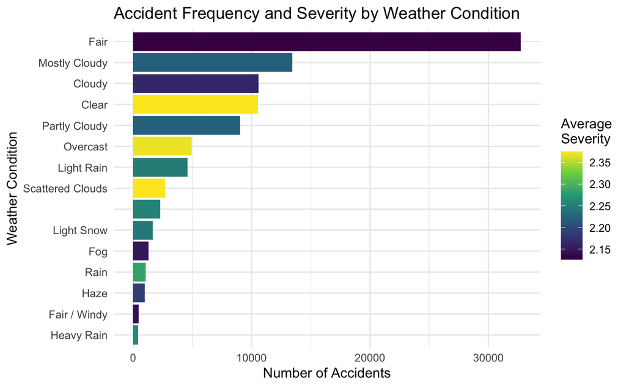

```r
ggplot(weather_summary,
    aes(x = reorder(Weather_Condition, count), y = count)) +
    geom_bar(stat = "identity", aes(fill = avg_severity)) +
    coord_flip() +
    scale_fill_viridis_c() +
    theme_minimal() +
    labs(
      title = "Accident Frequency and Severity by Weather Condition",
      x = "Weather Condition",
      y = "Number of Accidents",
      fill = "Average\nSeverity"
    )
```

# What hour of the day do accidents occur the most?

Here we will check if the hour of the day could tell us about accident frequency. I expect to see more accidents during peak hours.

```r
cleaned_accident_data <- cleaned_accident_data %>%
  mutate(hour = hour(Start_Time))
time_weather_summary <- cleaned_accident_data %>%
    group_by(hour) %>%
    summarise(
      count = n(),
      avg_severity = mean(Severity)
    )
```

## Graphing it

We see here that the hypothesis was correct. The peak hours which are during people leaving for work (6-9) and people coming back from work (3-6) has the most number of accidents. The severity of the accidents do not change a lot.

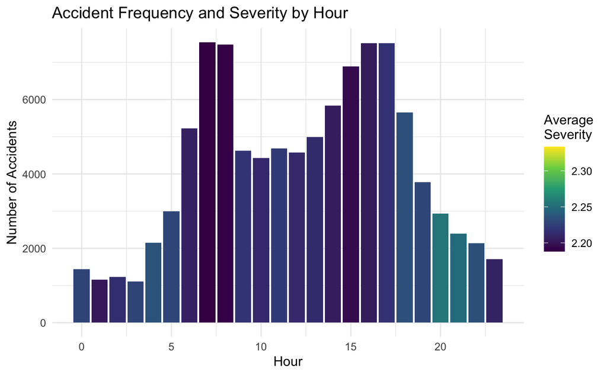

```r
ggplot(time_weather_summary,
    aes(x = hour, y = count)) +
    geom_bar(stat = "identity", aes(fill = avg_severity)) +
    scale_fill_viridis_c() +
    theme_minimal() +
    labs(
      title = "Accident Frequency and Severity by Hour",
      x = "Hour",
      y = "Number of Accidents",
      fill = "Average\nSeverity"
    )
```

# Does geography matter?

Here I want to analyze if the location, grouped by states can tell us about accident frequency or severity.

```r
# Getting data from ZipDemography
zip_data <- ZipDemography %>%
  filter(!is.na(Totalpopulation)) %>% # Remove rows not containing total population
  select(Totalpopulation, ZIP, Meantraveltimetoworkinminutespopulation16yearsandolder) # Only select required fields

# Removing '-' from zipcodes in accidents data. For example 123456-4123 -> 123456
cleaned_accident_data <- cleaned_accident_data %>%
  mutate(Zipcode = str_extract(Zipcode, "^[0-9]+")) # This matches a string with digits in the beginning until we see a non digit

# Join Accident Data with ZipDemography
accidents_with_zip_data <- cleaned_accident_data %>%
  left_join(zip_data, by = c(Zipcode = "ZIP"))
```

## Grouping by states

Here we group the data by states and count the total number of accidents.

```r
# Since zipcodes can be repeated in the joined accidents data, we need to first get the rows without duplicated zipcodes so we can use it to total population.
unique_zip_data <- accidents_with_zip_data %>%
  select(Zipcode, State, Totalpopulation) %>%
  distinct() # Removes duplicate ZIP codes

state_summary <- unique_zip_data %>%
  group_by(State) %>%
  summarise(
    total_population = sum(Totalpopulation, na.rm = TRUE) # Sum population for each zipcodes
  ) %>%
  left_join(
    accidents_with_zip_data %>% # Join it again so we can calculate the total number of accidents
      group_by(State) %>%
      summarise(
        total_accidents = n()
        ),
    by = "State"
  ) %>%
  arrange(desc(total_accidents))
top_10_states <- state_summary %>%
  slice_max(total_accidents, n = 10)
```

## Graphing Number of Accidents vs State

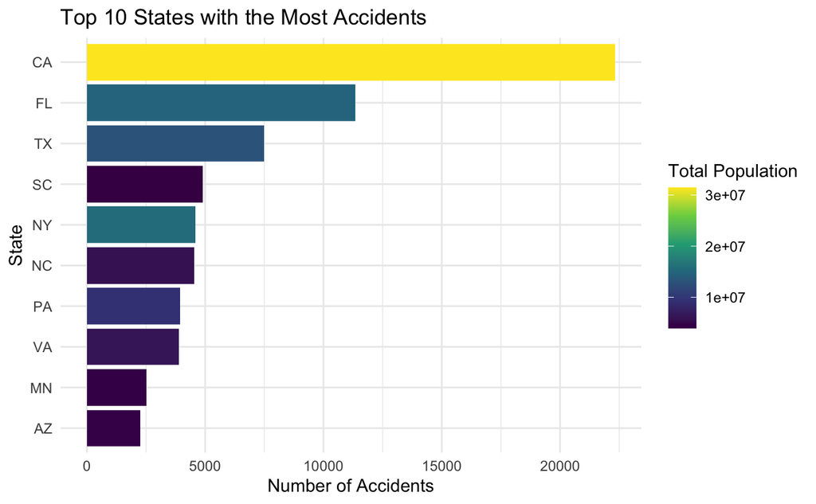

```r
ggplot(top_10_states, aes(x = reorder(State, total_accidents), y = total_accidents)) +
  geom_bar(stat = "identity", aes(fill = total_population)) +
  scale_fill_viridis_c() +
  theme_minimal() +
  coord_flip() +
  labs(
    title = "Top 10 States with the Most Accidents",
    x = "State",
    y = "Number of Accidents",
    fill = "Total Population"
  )
```

# Travel Time Analysis

Here we will check if travel time to work effects the accidents.

```r
travel_time_data <- accidents_with_zip_data %>%
  group_by(Zipcode) %>%
  summarise(
    mean_travel_time = mean(Meantraveltimetoworkinminutespopulation16yearsandolder, na.rm = TRUE), # Calculating mean travel time
    total_accidents = n()
  )
```

## Graphing travel time

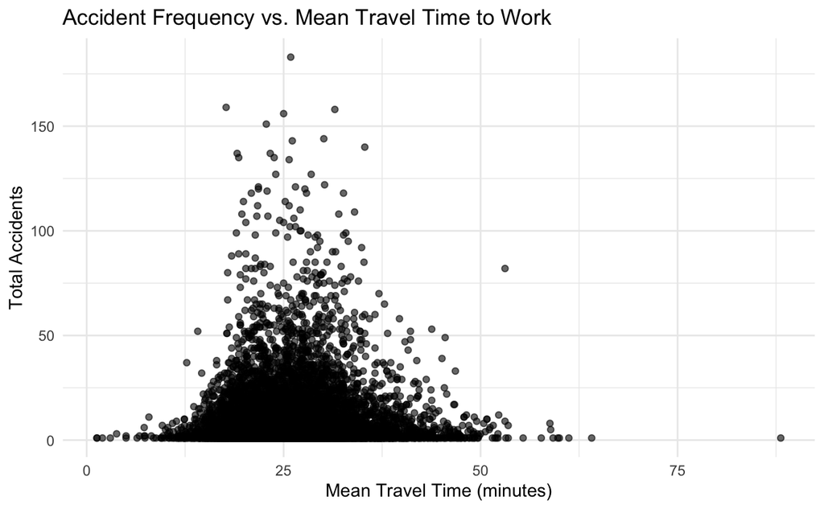

```r
ggplot(travel_time_data, aes(x = mean_travel_time, y = total_accidents)) +
  geom_point(alpha = 0.6) +
  labs(
    title = "Accident Frequency vs. Mean Travel Time to Work",
    x = "Mean Travel Time (minutes)",
    y = "Total Accidents"
  ) +
  theme_minimal()
```

## Conclusion

We saw that geographic and environmental aspects does have impact on the number and severity of accidents.